# Finding and Fixing Vulnerabilities Using AI – Validate findings

## 5.4 Validate findings

A vulnerability is a defect that can be exploited by an attacker and violates some security requirement. A finding is only a *potential* vulnerability. Not all findings from AIs (or humans) are real vulnerabilities [[Ottenheimer2026-05-26](https://www.flyingpenguin.com/mythos-grading-mythos-got-patches-yet/)]. Thus, once you have a finding, you need to *validate* it to independently determine if a finding is a vulnerability, a defect but not a vulnerability, or not a defect.

Even when a finding isn’t a defect, it might suggest improvements for the future. However, here we’ll focus on validating if a finding is a vulnerability.

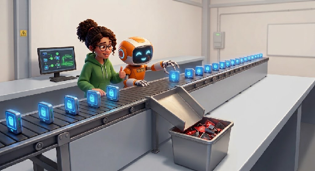

Human and AI working together to validate findings of potential vulnerabilities, rejecting some and accepting others.

### 5.4.1 Defining what a vulnerability is

A *key* for validating findings is to have a threat model and/or security requirements. Otherwise there’s no way to tell if something is security-related, making it difficult to determine if something is or isn’t a vulnerability. It’s also vital to have a validation infrastructure, that is, a way to run tests to confirm or refute claims [[Ziegler2026](https://xbow.com/blog/mythos-offensive-security-xbow-evaluation)].

An important decision is to decide if defense-in-depth countermeasures (such as sandboxes) should be disabled and ignored during validation. A mechanism is only a defense-in-depth measure if it’s an *additional* measure for security, not a *required* one. Thus, from a security perspective, it’s better if a finding is considered a vulnerability *even if* another countermeasure would have prevented it. For example, the Mozilla Firefox project considers a finding a vulnerability even if a sandbox would have prevented its exploitation. That way, “Real-world attackers generally need to chain multiple exploits together to escalate privileges through one or more layers [mitigations like sandboxing and ASLR] [[Grinstead2026-05](https://hacks.mozilla.org/2026/05/behind-the-scenes-hardening-firefox/)]. Of course, vulnerabilities that can penetrate existing countermeasures should be prioritized.

### 5.4.2 Defining the proof required

Projects must define the level of proof required for a finding to be considered a vulnerability within their project.  
Here are some key considerations:

1. The gold standard for validating a finding is to generate a Proof of Vulnerability (PoV), that is, a specific input to the program that an adversary *could* supply that causes the system to fail its security requirements.
   1. In practice, being able to trigger abnormal execution (such as a crash, memory error, or sanitizer violation) is often considered by many projects to be enough to prove that a discovered defect is real and reachable. For example, Firefox classifies findings as high security vulnerabilities “based on predictable crash symptoms such as use-after-free or out-of-bounds memory issues being reported by AddressSanitizer, and our threat model assumes that any of them could be exploitable with sufficient effort. This reduces the risk of a false negative during exploitability analysis, and more importantly it allows us to focus our resources on finding and fixing more vulnerabilities.” [[Grinstead2026-05](https://hacks.mozilla.org/2026/05/behind-the-scenes-hardening-firefox/)]
   2. Some AI systems incorporate guardrails that prevent creating a PoV (since it can also be used for an attack), making them useless for creating PoVs. In some cases defenders can request access from the AI system provider to a different model without such guardrails. Otherwise, a different AI system may be necessary to implement this task.
2. A project may decide that more general information that describes generally how to exploit the vulnerability, without details, is adequate evidence.
3. In the long term it’s often worthwhile to fix defects even if neither standard is met, since even if a PoV isn’t found it might be possible for a different system to find a way to exploit a finding. Typically the later triage focuses first on the findings that are *known* to be exploitable.

A *part* of validating findings is typically to use an AI to review the proposed finding. In principle a stronger model will be better at this, but it’s no guarantee. [[Ziegler2026](https://xbow.com/blog/mythos-offensive-security-xbow-evaluation)] reporting when using Mythos Preview that its “judgment results were more mixed than its discovery results… It rejected false positives better than many predecessors, but sometimes lost true positives when evidence did not formally satisfy its criteria or when the intended rule was broader than the written one.”

### 5.4.3 Tips for validation

Here are some tips for validating that a finding is (or is not) a vulnerability.

There’s no magic to validation. Validating claims has long been a part of software development. In the case of validating AI findings, [Khollosi] reported that “Practitioners in our study consistently emphasized a layered validation approach involving manual inspection, sandbox testing, peer review, and cross-checking against established standards such as OWASP or NIST.” It’s all part of using multiple stages to validate (and deduplicate) a report [[Rogers2025](https://joshua.hu/llm-engineer-review-sast-security-ai-tools-pentesters)].

[[Yan2026](https://claude.com/blog/using-llms-to-secure-source-code)] recommends the following for verification:

- The verifier agent should be independent from the discovery agent. A useful way to frame this is that validation involves **independent reproduction rather than self-review**. Asking the discovery agent to reconsider its *own* conclusion can preserve the same context, assumptions, and reasoning errors.”
- “The verifier should instead independently attempt to *disprove* the finding and produce reproducible evidence for its conclusion [[Yan2026](https://claude.com/blog/using-llms-to-secure-source-code)] [[Bourzikas2026](https://blog.cloudflare.com/cyber-frontier-models/)]. Run the verifier in a fresh container without a shared filesystem or conversation history. If the verifier is exposed to the discovery agent’s reasoning, it may simply agree instead of testing the claim. Thus, give the verifier only (1) the [proof of vulnerability] or written finding and (2) the codebase, so it can search for mitigations the finder missed (e.g., upstream validation, auth gates, type constraints, or unreachable code).”
- Another approach is to “prompt the verification agent to *disprove* the discovery agent’s findings [while still providing the full set of information available]. Have the verifier assume each finding is a false positive and search for reasons the finding is wrong. Include clear criteria that the verifier agent can use to determine if the finding is a true positive. This [approach] matters most when the discovery agent’s output doesn’t include a [Proof of Vulnerability (PoV)]. Aim to exclude as many non-exploitable findings as possible to reduce effort on manual reviews.”
- “Across the teams we’ve worked with, adding an *adversarial verifier* roughly *halved* the rate of *non-exploitable findings* from the discovery phase. Requiring that verifier to also build a [PoV] confirming the exploit brought the false positive rate to near zero. Together, these two steps helped to reduce the downstream triage and patching load significantly.”
- “One team scanning open-source packages built a verification step that helped to close the loop: scan the package, generate a proof of concept, then deploy a mock application that uses the package and triggers the [PoV]. Their take was that: “Validation is the biggest holdup and the [PoV] is the validation.””

In summary: ask a *separate* instance to *disprove* the findings, and if it can’t, demand a proof of vulnerability. These two steps can dramatically eliminate false positives, and doing them as a *separate* step means the AI system won’t abandon findings *too* quickly.

**Quiz**

Q1. Why does the Mozilla Firefox project consider a defect to be a vulnerability even when an existing countermeasure, such as a sandbox, would have prevented exploitation?

1. Because a defense-in-depth measure is by definition an *additional* protection, not a required one, so relying on it to excuse the underlying defect would weaken the system’s actual security.
2. Because Firefox’s threat model assumes that all sandboxes will eventually be disabled by end users, so no countermeasure can be trusted to remain active.
3. Because the CRA legally requires vendors to report every defect regardless of whether it’s exploitable, so classification is a compliance formality.
4. Because AI systems can’t reliably detect which countermeasures are active, so Firefox treats every defect as maximally severe to be safe.

**Show answer**

Answer: A